# TrabajoPersonal_AlvaroMartin

Álvaro Martín Lozano

1/28/2022

# **Analizando dataset nycflights13::flights**

Primero cargo los paquetes necesarios (“tidyverse” y “nycflights13”), previamente instalados. A continuación, creo 5 datasets con los datos del paquete “nycflights”.

```r
library(tidyverse)
library(lubridate)
library(nycflights13)
aerolineas <- nycflights13::airlines
aeropuertos <- nycflights13::airports
vuelos <- nycflights13::flights
aviones <- nycflights13::planes
clima <- nycflights13::weather
```

### **EJ 1**: Vuelos que llegaron más de 1 hora tarde de lo previsto

```r
vuelos_retrasados <- filter(vuelos, arr_delay>60)
vuelos_retrasados
```

```
## # A tibble: 27,789 × 19
##     year month   day dep_time sched_dep_time dep_delay arr_time sched_arr_time
##    <int> <int> <int>    <int>          <int>     <dbl>    <int>          <int>
##  1  2013     1     1      811            630       101     1047            830
##  2  2013     1     1      848           1835       853     1001           1950
##  3  2013     1     1      957            733       144     1056            853
##  4  2013     1     1     1114            900       134     1447           1222
##  5  2013     1     1     1120            944        96     1331           1213
##  6  2013     1     1     1255           1200        55     1451           1330
##  7  2013     1     1     1301           1150        71     1518           1345
##  8  2013     1     1     1337           1220        77     1649           1531
##  9  2013     1     1     1342           1320        22     1617           1504
## 10  2013     1     1     1400           1250        70     1645           1502
## # … with 27,779 more rows, and 11 more variables: arr_delay <dbl>,
## #   carrier <chr>, flight <int>, tailnum <chr>, origin <chr>, dest <chr>,
## #   air_time <dbl>, distance <dbl>, hour <dbl>, minute <dbl>, time_hour <dttm>
```

```r
dim(vuelos_retrasados)
```

```
## [1] 27789    19
```

Un total de 27789 vuelos llegaron a destino con más de 1 hora de retraso. En la data frame creada (“vuelos_retrasados”) pueden verse cuáles son.

### **EJ 2**: Vuelos que volaron hacia San Francisco (aeropuertos SFO y OAK)

```r
vuelos_sf <- filter(vuelos, dest == "SFO" | dest == "OAK")
vuelos_sf
```

```
## # A tibble: 13,643 × 19
##     year month   day dep_time sched_dep_time dep_delay arr_time sched_arr_time
##    <int> <int> <int>    <int>          <int>     <dbl>    <int>          <int>
##  1  2013     1     1      558            600        -2      923            937
##  2  2013     1     1      611            600        11      945            931
##  3  2013     1     1      655            700        -5     1037           1045
##  4  2013     1     1      729            730        -1     1049           1115
##  5  2013     1     1      734            737        -3     1047           1113
##  6  2013     1     1      745            745         0     1135           1125
##  7  2013     1     1      746            746         0     1119           1129
##  8  2013     1     1      803            800         3     1132           1144
##  9  2013     1     1      826            817         9     1145           1158
## 10  2013     1     1     1029           1030        -1     1427           1355
## # … with 13,633 more rows, and 11 more variables: arr_delay <dbl>,
## #   carrier <chr>, flight <int>, tailnum <chr>, origin <chr>, dest <chr>,
## #   air_time <dbl>, distance <dbl>, hour <dbl>, minute <dbl>, time_hour <dttm>
```

```r
dim(vuelos_sf)
```

```
## [1] 13643    19
```

```r
dim(vuelos_sf[vuelos_sf$dest=="SFO",])
```

```
## [1] 13331    19
```

```r
dim(vuelos_sf[vuelos_sf$dest=="OAK",])
```

```
## [1] 312  19
```

Un total de 13643 vuelos volaron hacia San Francisco, siendo de ellos:

- 13331 vuelos al aeropuerto SFO.
- 312 vuelos al aeropuerto OAK.

### **EJ 3**: Vuelos operados por United American (UA) o por American Airlines (AA)

```r
vuelos_american <- filter(vuelos, carrier == "UA" | carrier == "AA")
vuelos_american
```

```
## # A tibble: 91,394 × 19
##     year month   day dep_time sched_dep_time dep_delay arr_time sched_arr_time
##    <int> <int> <int>    <int>          <int>     <dbl>    <int>          <int>
##  1  2013     1     1      517            515         2      830            819
##  2  2013     1     1      533            529         4      850            830
##  3  2013     1     1      542            540         2      923            850
##  4  2013     1     1      554            558        -4      740            728
##  5  2013     1     1      558            600        -2      753            745
##  6  2013     1     1      558            600        -2      924            917
##  7  2013     1     1      558            600        -2      923            937
##  8  2013     1     1      559            600        -1      941            910
##  9  2013     1     1      559            600        -1      854            902
## 10  2013     1     1      606            610        -4      858            910
## # … with 91,384 more rows, and 11 more variables: arr_delay <dbl>,
## #   carrier <chr>, flight <int>, tailnum <chr>, origin <chr>, dest <chr>,
## #   air_time <dbl>, distance <dbl>, hour <dbl>, minute <dbl>, time_hour <dttm>
```

```r
dim(vuelos_american)
```

```
## [1] 91394    19
```

```r
dim(vuelos_american[vuelos_american$carrier=="UA",])
```

```
## [1] 58665    19
```

```r
dim(vuelos_american[vuelos_american$carrier=="AA",])
```

```
## [1] 32729    19
```

Un total de 91394 vuelos volaron con alguna de estas dos aerolíneas:

- 58665 vuelos operados por United American (UA).
- 32729 vuelos operados por American Airlines (AA).

### **EJ 4**: Vuelos que volaron en primavera (Abril, Mayo y Junio)

```r
vuelos_primavera <- filter(vuelos, month == 4 | month == 5 | month == 6)
vuelos_primavera
```

```
## # A tibble: 85,369 × 19
##     year month   day dep_time sched_dep_time dep_delay arr_time sched_arr_time
##    <int> <int> <int>    <int>          <int>     <dbl>    <int>          <int>
##  1  2013     4     1      454            500        -6      636            640
##  2  2013     4     1      509            515        -6      743            814
##  3  2013     4     1      526            530        -4      812            827
##  4  2013     4     1      534            540        -6      833            850
##  5  2013     4     1      542            545        -3      914            920
##  6  2013     4     1      543            545        -2      921            927
##  7  2013     4     1      551            600        -9      748            659
##  8  2013     4     1      552            600        -8      641            701
##  9  2013     4     1      553            600        -7      725            735
## 10  2013     4     1      554            600        -6      752            805
## # … with 85,359 more rows, and 11 more variables: arr_delay <dbl>,
## #   carrier <chr>, flight <int>, tailnum <chr>, origin <chr>, dest <chr>,
## #   air_time <dbl>, distance <dbl>, hour <dbl>, minute <dbl>, time_hour <dttm>
```

```r
dim(vuelos_primavera)
```

```
## [1] 85369    19
```

```r
dim(vuelos_primavera[vuelos_primavera$month==4,])
```

```
## [1] 28330    19
```

```r
dim(vuelos_primavera[vuelos_primavera$month==5,])
```

```
## [1] 28796    19
```

```r
dim(vuelos_primavera[vuelos_primavera$month==6,])
```

```
## [1] 28243    19
```

Un total de 85369 vuelos volaron en los meses de primavera:

- 28330 vuelos en Abril.
- 28796 vuelos en Mayo.
- 28243 vuelos en Junio

### **EJ 5**: Vuelos que llegaron más de 1 hora tarde, pero salieron con menos de 1 hora de retraso

```r
vuelos_retra2 <- filter(vuelos, arr_delay>60 & dep_delay<60)
vuelos_retra2
```

```
## # A tibble: 4,956 × 19
##     year month   day dep_time sched_dep_time dep_delay arr_time sched_arr_time
##    <int> <int> <int>    <int>          <int>     <dbl>    <int>          <int>
##  1  2013     1     1     1255           1200        55     1451           1330
##  2  2013     1     1     1342           1320        22     1617           1504
##  3  2013     1     1     1402           1323        39     1650           1526
##  4  2013     1     1     1411           1315        56     1717           1611
##  5  2013     1     1     1424           1349        35     1701           1556
##  6  2013     1     1     1428           1329        59     1803           1640
##  7  2013     1     1     1558           1534        24     1808           1703
##  8  2013     1     1     1604           1510        54     1817           1710
##  9  2013     1     1     1608           1535        33     2002           1850
## 10  2013     1     1     1630           1548        42     1902           1755
## # … with 4,946 more rows, and 11 more variables: arr_delay <dbl>,
## #   carrier <chr>, flight <int>, tailnum <chr>, origin <chr>, dest <chr>,
## #   air_time <dbl>, distance <dbl>, hour <dbl>, minute <dbl>, time_hour <dttm>
```

```r
dim(vuelos_retra2)
```

```
## [1] 4956   19
```

Un total de 4956 vuelos cumplieron esta condición.

### **EJ 6**: Vuelos que salieron con más de 1 hora de retraso, pero llegaron con menos de media hora de retraso

```r
vuelos_retra3 <- filter(vuelos, dep_delay>60 & arr_delay<30)
vuelos_retra3
```

[output not shown]

```r
dim(vuelos_retra3)
```

```
## [1] 181  19
```

Un total de 181 vuelos aceleraron en el aire, cumpliendo esta condición.

### **EJ 7**: Vuelos nocturnos

```r
vuelos_nocturnos <- filter(vuelos, hour<=7)
vuelos_nocturnos
```

```
## # A tibble: 50,726 × 19
##     year month   day dep_time sched_dep_time dep_delay arr_time sched_arr_time
##    <int> <int> <int>    <int>          <int>     <dbl>    <int>          <int>
##  1  2013     1     1      517            515         2      830            819
##  2  2013     1     1      533            529         4      850            830
##  3  2013     1     1      542            540         2      923            850
##  4  2013     1     1      544            545        -1     1004           1022
##  5  2013     1     1      554            600        -6      812            837
##  6  2013     1     1      554            558        -4      740            728
##  7  2013     1     1      555            600        -5      913            854
##  8  2013     1     1      557            600        -3      709            723
##  9  2013     1     1      557            600        -3      838            846
## 10  2013     1     1      558            600        -2      753            745
## # … with 50,716 more rows, and 11 more variables: arr_delay <dbl>,
## #   carrier <chr>, flight <int>, tailnum <chr>, origin <chr>, dest <chr>,
## #   air_time <dbl>, distance <dbl>, hour <dbl>, minute <dbl>, time_hour <dttm>
```

```r
dim(vuelos_nocturnos)
```

```
## [1] 50726    19
```

Hubo un total de 50726 vuelos nocturnos (operados entre la medianoche y las 7am).

### **EJ 8**: Vuelos con hora de salida desconocida

```r
vuelos_desconocidos <- filter(vuelos, is.na(dep_time))
vuelos_desconocidos
```

```
## # A tibble: 8,255 × 19
##     year month   day dep_time sched_dep_time dep_delay arr_time sched_arr_time
##    <int> <int> <int>    <int>          <int>     <dbl>    <int>          <int>
##  1  2013     1     1       NA           1630        NA       NA           1815
##  2  2013     1     1       NA           1935        NA       NA           2240
##  3  2013     1     1       NA           1500        NA       NA           1825
##  4  2013     1     1       NA            600        NA       NA            901
##  5  2013     1     2       NA           1540        NA       NA           1747
##  6  2013     1     2       NA           1620        NA       NA           1746
##  7  2013     1     2       NA           1355        NA       NA           1459
##  8  2013     1     2       NA           1420        NA       NA           1644
##  9  2013     1     2       NA           1321        NA       NA           1536
## 10  2013     1     2       NA           1545        NA       NA           1910
## # … with 8,245 more rows, and 11 more variables: arr_delay <dbl>,
## #   carrier <chr>, flight <int>, tailnum <chr>, origin <chr>, dest <chr>,
## #   air_time <dbl>, distance <dbl>, hour <dbl>, minute <dbl>, time_hour <dttm>
```

```r
dim(vuelos_desconocidos)
```

```
## [1] 8255   19
```

Un total de 8255 vuelos tienen un valor desconocido de “dep_time”, lo que puede indicar probablemente que fueron vuelos cancelados (no llegaron a salir).

### **EJ 9**: Variables que contienen datos desconocidos

```r
apply(is.na(vuelos),2,sum)
```

```
##           year          month            day       dep_time sched_dep_time
##              0              0              0           8255              0
##      dep_delay       arr_time sched_arr_time      arr_delay        carrier
##           8255           8713              0           9430              0
##         flight        tailnum         origin           dest       air_time
##              0           2512              0              0           9430
##       distance           hour         minute      time_hour
##              0              0              0              0
```

Las variables (columnas) que contienen valores desconocidos son:

- dep_time
- dep_delay
- arr_time
- arr_delay
- tailnum
- air_time

### **EJ 10**: Vuelos más y menos retrasados en la salida

Los vuelos más retrasados a la hora de salida (mayor “dep_delay”), ordenados de mayor a menor, fueron:

```r
arrange(vuelos, desc(dep_delay))
```

```
## # A tibble: 336,776 × 19
##     year month   day dep_time sched_dep_time dep_delay arr_time sched_arr_time
##    <int> <int> <int>    <int>          <int>     <dbl>    <int>          <int>
##  1  2013     1     9      641            900      1301     1242           1530
##  2  2013     6    15     1432           1935      1137     1607           2120
##  3  2013     1    10     1121           1635      1126     1239           1810
##  4  2013     9    20     1139           1845      1014     1457           2210
##  5  2013     7    22      845           1600      1005     1044           1815
##  6  2013     4    10     1100           1900       960     1342           2211
##  7  2013     3    17     2321            810       911      135           1020
##  8  2013     6    27      959           1900       899     1236           2226
##  9  2013     7    22     2257            759       898      121           1026
## 10  2013    12     5      756           1700       896     1058           2020
## # … with 336,766 more rows, and 11 more variables: arr_delay <dbl>,
## #   carrier <chr>, flight <int>, tailnum <chr>, origin <chr>, dest <chr>,
## #   air_time <dbl>, distance <dbl>, hour <dbl>, minute <dbl>, time_hour <dttm>
```

Los vuelos más adelantados a la hora de salida (“dep_delay” negativo) fueron:

```r
arrange(vuelos, dep_delay)
```

```
## # A tibble: 336,776 × 19
##     year month   day dep_time sched_dep_time dep_delay arr_time sched_arr_time
##    <int> <int> <int>    <int>          <int>     <dbl>    <int>          <int>
##  1  2013    12     7     2040           2123       -43       40           2352
##  2  2013     2     3     2022           2055       -33     2240           2338
##  3  2013    11    10     1408           1440       -32     1549           1559
##  4  2013     1    11     1900           1930       -30     2233           2243
##  5  2013     1    29     1703           1730       -27     1947           1957
##  6  2013     8     9      729            755       -26     1002            955
##  7  2013    10    23     1907           1932       -25     2143           2143
##  8  2013     3    30     2030           2055       -25     2213           2250
##  9  2013     3     2     1431           1455       -24     1601           1631
## 10  2013     5     5      934            958       -24     1225           1309
## # … with 336,766 more rows, and 11 more variables: arr_delay <dbl>,
## #   carrier <chr>, flight <int>, tailnum <chr>, origin <chr>, dest <chr>,
## #   air_time <dbl>, distance <dbl>, hour <dbl>, minute <dbl>, time_hour <dttm>
```

### **EJ 11**: Vuelos más rápidos

Creo una nueva columna llamada “velocidad”, donde calculo el valor de la velocidad de cada avión, entendida como el cociente entre la distancia recorrida entre los aeropuertos (en millas) y el tiempo (en horas) necesario para recorrer dicha distancia. Finalmente, se muestran ordenados los aviones más rápidos.

```r
vuelos$velocidad <- vuelos$distance/(vuelos$air_time/60) #(millas/hora)
arrange(vuelos, desc(velocidad))
```

```
## # A tibble: 336,776 × 20
##     year month   day dep_time sched_dep_time dep_delay arr_time sched_arr_time
##    <int> <int> <int>    <int>          <int>     <dbl>    <int>          <int>
##  1  2013     5    25     1709           1700         9     1923           1937
##  2  2013     7     2     1558           1513        45     1745           1719
##  3  2013     5    13     2040           2025        15     2225           2226
##  4  2013     3    23     1914           1910         4     2045           2043
##  5  2013     1    12     1559           1600        -1     1849           1917
##  6  2013    11    17      650            655        -5     1059           1150
##  7  2013     2    21     2355           2358        -3      412            438
##  8  2013    11    17      759            800        -1     1212           1255
##  9  2013    11    16     2003           1925        38       17             36
## 10  2013    11    16     2349           2359       -10      402            440
## # … with 336,766 more rows, and 12 more variables: arr_delay <dbl>,
## #   carrier <chr>, flight <int>, tailnum <chr>, origin <chr>, dest <chr>,
## #   air_time <dbl>, distance <dbl>, hour <dbl>, minute <dbl>, time_hour <dttm>,
## #   velocidad <dbl>
```

### **EJ 12**: Vuelos con trayectos más largos

Los vuelos con trayectos (entre aeropuertos de origen y destino) más largos (en millas) fueron:

```r
arrange(vuelos, desc(distance))
```

```
## # A tibble: 336,776 × 20
##     year month   day dep_time sched_dep_time dep_delay arr_time sched_arr_time
##    <int> <int> <int>    <int>          <int>     <dbl>    <int>          <int>
##  1  2013     1     1      857            900        -3     1516           1530
##  2  2013     1     2      909            900         9     1525           1530
##  3  2013     1     3      914            900        14     1504           1530
##  4  2013     1     4      900            900         0     1516           1530
##  5  2013     1     5      858            900        -2     1519           1530
##  6  2013     1     6     1019            900        79     1558           1530
##  7  2013     1     7     1042            900       102     1620           1530
##  8  2013     1     8      901            900         1     1504           1530
##  9  2013     1     9      641            900      1301     1242           1530
## 10  2013     1    10      859            900        -1     1449           1530
## # … with 336,766 more rows, and 12 more variables: arr_delay <dbl>,
## #   carrier <chr>, flight <int>, tailnum <chr>, origin <chr>, dest <chr>,
## #   air_time <dbl>, distance <dbl>, hour <dbl>, minute <dbl>, time_hour <dttm>,
## #   velocidad <dbl>
```

### **EJ 13**: Vuelos con trayectos más cortos

Los vuelos con trayectos más cortos (en millas) fueron:

```r
arrange(vuelos, distance)
```

```
## # A tibble: 336,776 × 20
##     year month   day dep_time sched_dep_time dep_delay arr_time sched_arr_time
##    <int> <int> <int>    <int>          <int>     <dbl>    <int>          <int>
##  1  2013     7    27       NA            106        NA       NA            245
##  2  2013     1     3     2127           2129        -2     2222           2224
##  3  2013     1     4     1240           1200        40     1333           1306
##  4  2013     1     4     1829           1615       134     1937           1721
##  5  2013     1     4     2128           2129        -1     2218           2224
##  6  2013     1     5     1155           1200        -5     1241           1306
##  7  2013     1     6     2125           2129        -4     2224           2224
##  8  2013     1     7     2124           2129        -5     2212           2224
##  9  2013     1     8     2127           2130        -3     2304           2225
## 10  2013     1     9     2126           2129        -3     2217           2224
## # … with 336,766 more rows, and 12 more variables: arr_delay <dbl>,
## #   carrier <chr>, flight <int>, tailnum <chr>, origin <chr>, dest <chr>,
## #   air_time <dbl>, distance <dbl>, hour <dbl>, minute <dbl>, time_hour <dttm>,
## #   velocidad <dbl>
```

### **EJ 14**: Convertir el dato de “dep_time” en minutos transcurridos desde medianoche

El operador **%/%** devuelve el cociente de una división (sin el resto). Puede servir para obtener las horas enteras del dato de dep_time. El operador **%%** devuelve el resto de una división. Puede servir para obtener los minutos (sin horas) de dep_time. Así, podemos crear una nueva variable (columna) que nos devuelva este tiempo total transcurrido en minutos:

```r
vuelos$dep_time_min <- ((vuelos$dep_time %/% 100)*60) + (vuelos$dep_time %% 100)
vuelos$sched_dep_time_min <- ((vuelos$sched_dep_time %/% 100)*60) + (vuelos$sched_dep_time %% 100)
```

Del mismo modo, otra forma es emplear la función “mutate”, que se encarga de crear nuevas variables según las indiciaciones:

```r
mutate(vuelos,
          dep_time,
          hour_dep = dep_time %/% 100,
          minute_dep = dep_time %% 100,
          dep_time_min = ((vuelos$dep_time %/% 100)*60) + (vuelos$dep_time %% 100),
          sched_dep_time,
          sched_dep_time_min = ((vuelos$sched_dep_time %/% 100)*60) + (vuelos$sched_dep_time %% 100))
```

```
## # A tibble: 336,776 × 24
##     year month   day dep_time sched_dep_time dep_delay arr_time sched_arr_time
##    <int> <int> <int>    <int>          <int>     <dbl>    <int>          <int>
##  1  2013     1     1      517            515         2      830            819
##  2  2013     1     1      533            529         4      850            830
##  3  2013     1     1      542            540         2      923            850
##  4  2013     1     1      544            545        -1     1004           1022
##  5  2013     1     1      554            600        -6      812            837
##  6  2013     1     1      554            558        -4      740            728
##  7  2013     1     1      555            600        -5      913            854
##  8  2013     1     1      557            600        -3      709            723
##  9  2013     1     1      557            600        -3      838            846
## 10  2013     1     1      558            600        -2      753            745
## # … with 336,766 more rows, and 16 more variables: arr_delay <dbl>,
## #   carrier <chr>, flight <int>, tailnum <chr>, origin <chr>, dest <chr>,
## #   air_time <dbl>, distance <dbl>, hour <dbl>, minute <dbl>, time_hour <dttm>,
## #   velocidad <dbl>, dep_time_min <dbl>, sched_dep_time_min <dbl>,
## #   hour_dep <dbl>, minute_dep <dbl>
```

### **EJ 15**: Relación entre las variables “dep_delay”, “dep_time” y “sched_dep_time”

Para comprobar que realmente es así, y partiendo de la estrategia del ejercicio anterior, podemos calcular nosotros mismos esta diferencia de tiempo en minutos (a partir de las variables “dep_time_min” y “sched_dep_time_min” que habíamos creado antes), y compararla con la variable real “dep_delay”:

```r
vuelos$dep_delay_min <- vuelos$dep_time_min - vuelos$sched_dep_time_min
vuelos$dif_dep_delay <- vuelos$dep_delay - vuelos$dep_delay_min
table(vuelos$dif_dep_delay)
```

```
##
##      0   1440
## 327314   1207
```

Al hacer un table de la nueva variable diferencia (“dif_dep_delay”), vemos que la gran mayoría de los valores son 0, lo que significa que nuestros valores y los de la variable real coinciden y son correctos. No obstante, encontramos hasta 1207 valores de “dep_delay” con un registro de 1440 minutos de más que los calculados con nuestra diferencia. Si nos fijamos, estos 1440min coinciden con 24h, lo que indica un posible desajuste de los datos al retrasarse un vuelo sobrepasando la medianoche, y sumando 24horas más de diferencia que son irreales. Por tanto, deberíamos rectificar estos datos de “dep_delay” restándole 1440min.

### **EJ 16**: Patrón del número de vuelos que se cancelan cada día

Creo un nuevo data frame que agrupe los vuelos por días, y para cada día calculo el número total de vuelos y el número de vuelos que fueron cancelados (los que no tienen valores (NA) asignados al retraso de salida y llegada, porque no llegaron a volar):

```r
vuelos_cancel_dia <-  vuelos %>%
  mutate(vuelos_cancel = (is.na(arr_delay) | is.na(arr_delay))) %>%
  group_by(year, month, day) %>%
  summarise(cancelados = sum(vuelos_cancel), totales = n(),)
vuelos_cancel_dia
```

```
## # A tibble: 365 × 5
## # Groups:   year, month [12]
##     year month   day cancelados totales
##    <int> <int> <int>      <int>   <int>
##  1  2013     1     1         11     842
##  2  2013     1     2         15     943
##  3  2013     1     3         14     914
##  4  2013     1     4          7     915
##  5  2013     1     5          3     720
##  6  2013     1     6          3     832
##  7  2013     1     7          3     933
##  8  2013     1     8          7     899
##  9  2013     1     9          9     902
## 10  2013     1    10          3     932
## # … with 355 more rows
```

Representando estos datos podemos observar que, **a mayor número de vuelos operados al día, mayor era el número de vuelos que resultaban cancelados**.

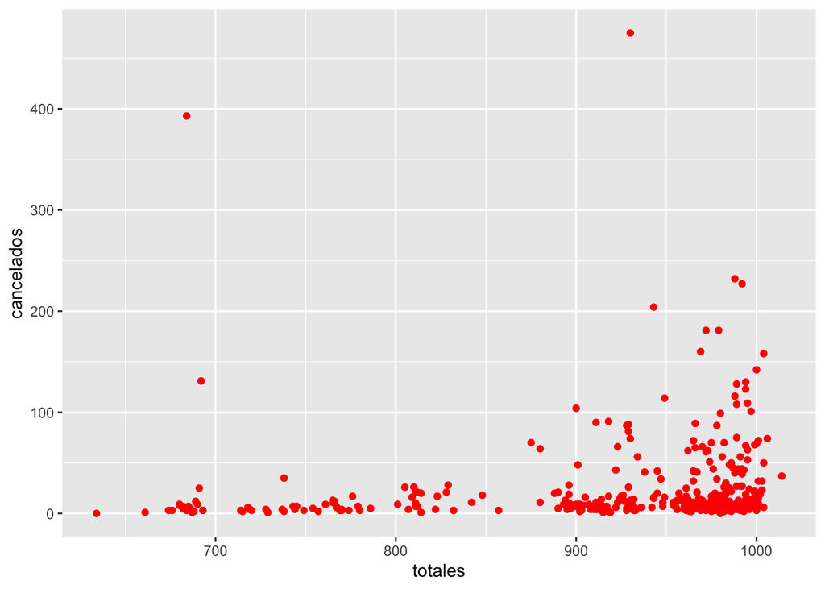

```r
ggplot(data=vuelos_cancel_dia) +
  geom_point(mapping=aes(x=totales, y=cancelados), color="red")
```

### **EJ 17**: Relación entre la proporción de vuelos cancelados y el retraso promedio, por día

Primero creamos un nuevo data frame que, agrupando los vuelos por día, incluya los valores de retraso medio y la proporción de los vuelos cancelados cada día.

```r
cancel_retraso_dia <- vuelos %>%
  mutate(cancelados = (is.na(tailnum))) %>%
  group_by(year, month, day) %>%
  summarise(ratio_cancelados = mean(cancelados),
            media_dep_delay = mean(dep_delay, na.rm = TRUE)) %>%
  ungroup()
cancel_retraso_dia
```

```
## # A tibble: 365 × 5
##     year month   day ratio_cancelados media_dep_delay
##    <int> <int> <int>            <dbl>           <dbl>
##  1  2013     1     1          0                 11.5
##  2  2013     1     2          0.00212           13.9
##  3  2013     1     3          0.00219           11.0
##  4  2013     1     4          0.00219            8.95
##  5  2013     1     5          0.00139            5.73
##  6  2013     1     6          0                  7.15
##  7  2013     1     7          0.00107            5.42
##  8  2013     1     8          0.00111            2.55
##  9  2013     1     9          0.00222            2.28
## 10  2013     1    10          0.00215            2.84
## # … with 355 more rows
```

Representando la proporción de vuelos cancelados frente a la media de retrasos al día, se puede observar una tendencia a un **mayor número de cancelaciones conforme aumenta el retraso**, destacando un gran pico de cancelaciones a valores de media de retrasos a partir de media_dep_delay =~ 15

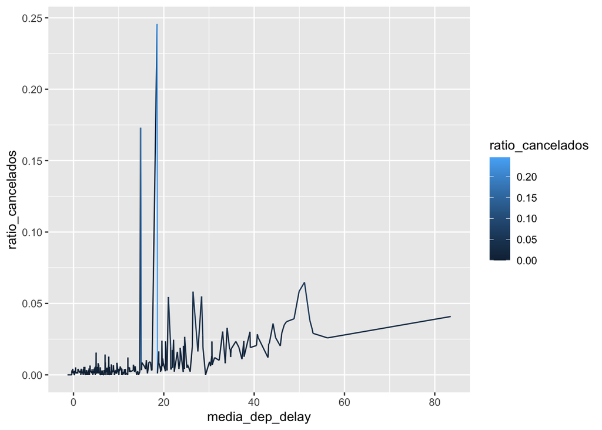

```r
ggplot(data=cancel_retraso_dia) +
  geom_line(aes(x=media_dep_delay, y=ratio_cancelados, col=ratio_cancelados))
```

### **EJ 18**: Relación entre la proporción de vuelos cancelados y el retraso promedio, por aeropuerto

Procedemos igual que en el ejemplo anterior, con la diferencia de que esta vez filtraremos la nueva data frame según los aeropuertos de origen y destino de los vuelos.

```r
cancel_retraso_aerop <- vuelos %>%
  mutate(cancelados = (is.na(tailnum))) %>%
  group_by(origin, dest) %>%
  summarise(ratio_cancelados = mean(cancelados),
            media_dep_delay = mean(dep_delay, na.rm = TRUE)) %>%
  ungroup()
cancel_retraso_aerop
```

```
## # A tibble: 224 × 4
##    origin dest  ratio_cancelados media_dep_delay
##    <chr>  <chr>            <dbl>           <dbl>
##  1 EWR    ALB           0                  23.6
##  2 EWR    ANC           0                  12.9
##  3 EWR    ATL           0                  15.5
##  4 EWR    AUS           0.00723            11.5
##  5 EWR    AVL           0                   8.62
##  6 EWR    BDL           0.00226            17.7
##  7 EWR    BNA           0.000428           17.7
##  8 EWR    BOS           0.00788            12.5
##  9 EWR    BQN           0.00337            23.9
## 10 EWR    BTV           0                  17.8
## # … with 214 more rows
```

Representando esta proporción de vuelos cancelados frente a la media de retrasos en función de los aeropuertos de origen y destino, **no observamos ninguna relación significativa** entre ambas variables, tendiendo a pensar que los aeropuertos no influyen “a priori” en los retrasos y cancelaciones.

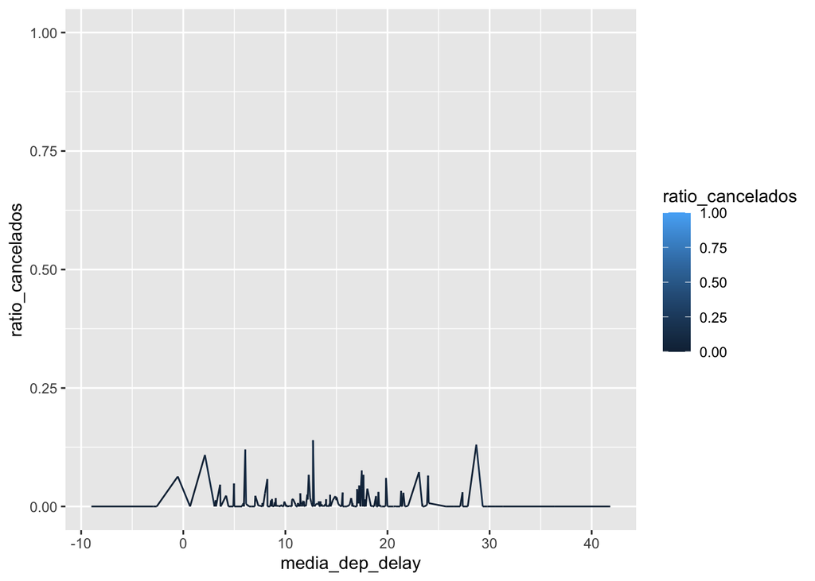

```r
ggplot(data=cancel_retraso_aerop) +
  geom_line(aes(x=media_dep_delay, y=ratio_cancelados, col=ratio_cancelados))
```

### **EJ 19**: Compañía aérea que sufre los mayores retrasos

Creo un data frame que, agrupado por aerolíneas, muestre el valor medio de retraso tanto a la salida (“dep_delay”) como a la llegada (“arr_delay”) de los vuelos:

```r
by_carrier <- group_by(vuelos, carrier)
retrasos <- summarise(by_carrier,
                      dep_delay = mean(dep_delay, na.rm = TRUE),
                      arr_delay = mean(arr_delay, na.rm = TRUE))
```

Retrasos a la salida de los vuelos, ordenados de mayor a menor:

```r
arrange(retrasos, desc(dep_delay))
```

```
## # A tibble: 16 × 3
##    carrier dep_delay arr_delay
##    <chr>       <dbl>     <dbl>
##  1 F9          20.2     21.9
##  2 EV          20.0     15.8
##  3 YV          19.0     15.6
##  4 FL          18.7     20.1
##  5 WN          17.7      9.65
##  6 9E          16.7      7.38
##  7 B6          13.0      9.46
##  8 VX          12.9      1.76
##  9 OO          12.6     11.9
## 10 UA          12.1      3.56
## 11 MQ          10.6     10.8
## 12 DL           9.26     1.64
## 13 AA           8.59     0.364
## 14 AS           5.80    -9.93
## 15 HA           4.90    -6.92
## 16 US           3.78     2.13
```

Retrasos a la llegada de los vuelos, ordenados de mayor a menor:

```r
arrange(retrasos, desc(arr_delay))
```

```
## # A tibble: 16 × 3
##    carrier dep_delay arr_delay
##    <chr>       <dbl>     <dbl>
##  1 F9          20.2     21.9
##  2 FL          18.7     20.1
##  3 EV          20.0     15.8
##  4 YV          19.0     15.6
##  5 OO          12.6     11.9
##  6 MQ          10.6     10.8
##  7 WN          17.7      9.65
##  8 B6          13.0      9.46
##  9 9E          16.7      7.38
## 10 UA          12.1      3.56
## 11 US           3.78     2.13
## 12 VX          12.9      1.76
## 13 DL           9.26     1.64
## 14 AA           8.59     0.364
## 15 HA           4.90    -6.92
## 16 AS           5.80    -9.93
```

Como podemos ver en ambos casos, la compañía **F9 (Frontier Airlines Inc.)** es la que sufre mayores retrasos, tanto a las salidas como, por consecuecia, a las llegadas de los vuelos.

### **EJ 20**: Horarios con menos retrasos en la salida del vuelo

Siguiendo la estrategia del ejercicio anterior, pero esta vez agrupando por horas de salida del vuelo (variable “hour”):

```r
by_hour <- group_by(vuelos, hour)
retrasos_hora <- summarise(by_hour,
                           dep_delay = mean(dep_delay, na.rm = TRUE))
arrange(retrasos_hora, dep_delay)
```

```
## # A tibble: 20 × 2
##     hour dep_delay
##    <dbl>     <dbl>
##  1     5     0.688
##  2     6     1.64
##  3     7     1.91
##  4     8     4.13
##  5     9     4.58
##  6    10     6.50
##  7    11     7.19
##  8    12     8.61
##  9    13    11.4
## 10    14    13.8
## 11    23    14.0
## 12    15    16.9
## 13    16    18.8
## 14    22    18.8
## 15    17    21.1
## 16    18    21.1
## 17    21    24.2
## 18    20    24.3
## 19    19    24.8
## 20     1   NaN
```

Vemos que las **primeras horas del día** (los vuelos de las 5am sobre todo) son las que nos aseguran una tasa de retraso menor, en comparación con otras franjas horarias.

### **EJ 21**: Mejor día de la semana para volar evitando los retrasos

Primero creo una función para calcular el día de la semana que se corresponde con la fecha exacta de cada vuelo, aprovechando la función “make_daytime()” de la librería “lubritade”.

```r
make_dtime <- function(year, month, day, time)
{
  make_datetime(year, month, day, time %/% 100, time %% 100)
}
```

Transformo los datos hora de salida y llegada (y retrasos) de los vuelos en fecha y hora, gracias a esta función creada, y guardo esta información en un data frame (“vuelos_dt”). A continuación, devuelvo los valores de retrasos a la salida y llegada de cada uno:

```r
vuelos_dt <- vuelos %>%
  filter(!is.na(dep_time), !is.na(arr_time)) %>%
  mutate(
    dep_time = make_dtime(year, month, day, dep_time),
    arr_time = make_dtime(year, month, day, arr_time),
    sched_dep_time = make_dtime(year, month, day, sched_dep_time),
    sched_arr_time = make_dtime(year, month, day, sched_arr_time)
  ) %>%
  select(origin, dest, ends_with("delay"), ends_with("time"))
vuelos_dt %>%
  mutate(dow = wday(sched_dep_time)) %>%
  group_by(dow) %>%
  summarise(
    dep_delay = mean(dep_delay),
    arr_delay = mean(arr_delay, na.rm = TRUE)
  ) %>%
  print(n = Inf)
```

```
## # A tibble: 7 × 3
##     dow dep_delay arr_delay
##   <dbl>     <dbl>     <dbl>
## 1     1     11.5       4.82
## 2     2     14.7       9.65
## 3     3     10.6       5.39
## 4     4     11.7       7.05
## 5     5     16.1      11.7
## 6     6     14.7       9.07
## 7     7      7.62     -1.45
```

Finalmente, represento el promedio de retrasos en las salidas de los vuelos para cada día de la semana:

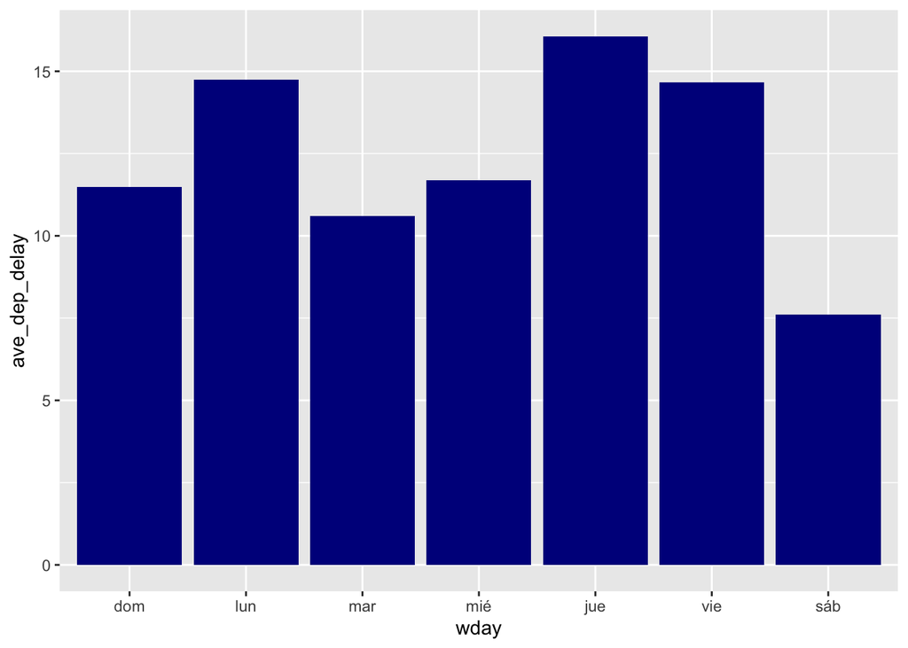

```r
vuelos_dt %>%
  mutate(wday = wday(dep_time, label = TRUE)) %>%
  group_by(wday) %>%
  summarize(ave_dep_delay = mean(dep_delay, na.rm = TRUE)) %>%
  ggplot(aes(x = wday, y = ave_dep_delay)) +
  geom_bar(stat = "identity", fill = "dark blue")
```

Visualizando la gráfica, encontramos más conveniente coger un vuelo los **sábados** para evitar los retrasos en las salidas. Por el contrario, vemos que los jueves, viernes y lunes son los días en los que más retrasos se producen.

### **EJ 22**: Total de minutos de retraso para cada destino

```r
vuelos$arr_delay_min <- ((vuelos$arr_delay %/% 100)*60) + (vuelos$arr_delay %% 100)
```

Ahora puedo crear un data frame, agrupando por destinos, y calculo el total de minutos de retraso en la llegada para cada aeropuerto de destino:

```r
by_destino <- group_by(vuelos, dest)
retraso_destino <- summarise(by_destino,
                             arr_delay = sum(arr_delay_min, na.rm = TRUE))
retraso_destino
```

```
## # A tibble: 105 × 2
##    dest  arr_delay
##    <chr>     <dbl>
##  1 ABQ        6393
##  2 ACK        7241
##  3 ALB       13818
##  4 ANC         100
##  5 ATL      489500
##  6 AUS       65434
##  7 AVL        7169
##  8 BDL       12504
##  9 BGR       10554
## 10 BHM        9100
## # … with 95 more rows
```

### **EJ 23**: Proporción del total de retraso para cada destino

Dentro de cada aeropuerto de destino, conociendo anteriormente el total de minutos de retraso acumulado por dicho aeropuerto, calculo el ratio de retraso para cada vuelo que llegó retrasado a dicho aeropuerto:

```r
vuelos %>%
  filter(arr_delay > 0) %>%
  group_by(dest, origin, carrier, flight) %>%
  summarise(arr_delay = sum(arr_delay)) %>%
  group_by(dest) %>%
  mutate(
    arr_delay_prop = arr_delay / sum(arr_delay)
  ) %>%
  arrange(dest, desc(arr_delay_prop)) %>%
  select(carrier, flight, origin, dest, arr_delay_prop)
```

```
## # A tibble: 8,834 × 5
## # Groups:   dest [103]
##    carrier flight origin dest  arr_delay_prop
##    <chr>    <int> <chr>  <chr>          <dbl>
##  1 B6        1505 JFK    ABQ           0.567
##  2 B6          65 JFK    ABQ           0.433
##  3 B6        1191 JFK    ACK           0.475
##  4 B6        1491 JFK    ACK           0.414
##  5 B6        1291 JFK    ACK           0.0898
##  6 B6        1195 JFK    ACK           0.0208
##  7 EV        4309 EWR    ALB           0.174
##  8 EV        4271 EWR    ALB           0.137
##  9 EV        4117 EWR    ALB           0.0951
## 10 EV        4088 EWR    ALB           0.0865
## # … with 8,824 more rows
```

### **EJ 24**: ¿Qué se deduce acerca de los retrasos según la hora del día a la que está programada el vuelo de salida?

Para interpretarlo, represento la hora de salida con retraso frente a las horas de salida programadas para cada vuelo, partiendo del data frame “vuelos_dt” previamente creado (Ejercicio 21):

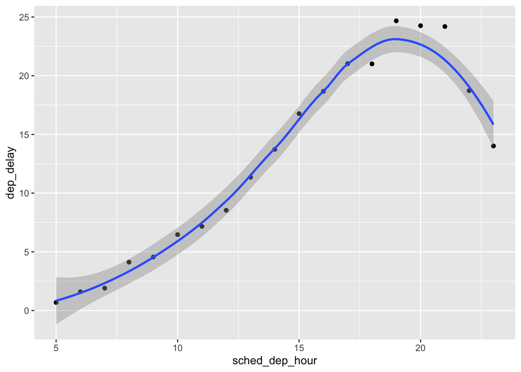

```r
vuelos_dt %>%
  mutate(sched_dep_hour = hour(sched_dep_time)) %>%
  group_by(sched_dep_hour) %>%
  summarise(dep_delay = mean(dep_delay)) %>%
  ggplot(aes(y = dep_delay, x = sched_dep_hour)) +
  geom_point() +
  geom_smooth()
```

Claramente la gráfica nos muestra cómo el mayor pico de retrasos se acumulan en los vuelos que tienen una hora de salida programada **por la tarde (con un pico máximo alrededor de las 7pm)**, quizá por la mayor afluencia de vuelos y pasajeros a esas horas en el aeropuerto.

### **EJ 25**: URL de GitHub

Pinchar [aquí](https://github.com/alvaromlz/TrabajoPersonal.git) para ir al proyecto online compartido de GitHub (“TrabajoPersonal” - Álvaro Martín Lozano)